# Analyzing IMDb datasets

**Authors:** - Dirk Beekmans - Hugo Reniers - Sjors Boelaars - Parisa Vatankh - Dani Visser

# Introduction

This report provides an analysis of two IMDb datasets: one containing information about titles and another with ratings and votes. The datasets are described below:

## Titles

### Description

The titles dataset contains information about various titles, including movies, TV series, and more. Below are the variables included in this dataset:

- `tconst` (string): Alphanumeric unique identifier of the title.
- `titleType` (string): The type/format of the title (e.g., movie, short, tvseries, tvepisode, video, etc).
- `primaryTitle` (string): The more popular title or the title used by filmmakers for promotional materials.
- `originalTitle` (string): The original title in the original language.
- `isAdult` (boolean): 0 for non-adult titles; 1 for adult titles.
- `startYear` (YYYY): Represents the release year of a title. For TV series, it is the series start year.
- `endYear` (YYYY): TV series end year. Use ‘’ for all other title types.
- `runtimeMinutes`: The primary runtime of the title in minutes.
- `genres` (string array): Includes up to three genres associated with the title.

## Ratings and Votes Dataset

### Description

The ratings and votes dataset contains information about the ratings and votes received by titles. Here are the variables in this dataset:

- `tconst` (string): Alphanumeric unique identifier of the title.
- `averageRating`: Weighted average of all individual user ratings.
- `numVotes`: The number of votes the title has received.

# Data Exploration

In this section, we’ll explore both datasets to gain insights into the data.

## Titles Dataset Exploration

### Summary Statistics

#### Before filtering the data

Let’s start by examining some summary statistics for the titles dataset:

```r
summary(titles)
```

```
##     tconst           titleType         primaryTitle       originalTitle
##  Length:10223035    Length:10223035    Length:10223035    Length:10223035
##  Class :character   Class :character   Class :character   Class :character
##  Mode  :character   Mode  :character   Mode  :character   Mode  :character
##
##
##
##
##     isAdult           startYear           endYear          runtimeMinutes
##  Min.   :   0.0000   Length:10223035    Length:10223035    Length:10223035
##  1st Qu.:   0.0000   Class :character   Class :character   Class :character
##  Median :   0.0000   Mode  :character   Mode  :character   Mode  :character
##  Mean   :   0.0361
##  3rd Qu.:   0.0000
##  Max.   :2023.0000
##  NA's   :1
##     genres
##  Length:10223035
##  Class :character
##  Mode  :character
##
##
##
##
```

```r
head(titles)
```

```
## # A tibble: 6 × 9
##   tconst    titleType primaryTitle       originalTitle isAdult startYear endYear
##   <chr>     <chr>     <chr>              <chr>           <dbl> <chr>     <chr>
## 1 tt0000001 short     Carmencita         Carmencita          0 1894      "\\N"
## 2 tt0000002 short     Le clown et ses c… Le clown et …       0 1892      "\\N"
## 3 tt0000003 short     Pauvre Pierrot     Pauvre Pierr…       0 1892      "\\N"
## 4 tt0000004 short     Un bon bock        Un bon bock         0 1892      "\\N"
## 5 tt0000005 short     Blacksmith Scene   Blacksmith S…       0 1893      "\\N"
## 6 tt0000006 short     Chinese Opium Den  Chinese Opiu…       0 1894      "\\N"
## # ℹ 2 more variables: runtimeMinutes <chr>, genres <chr>
```

#### After filtering and cleaning the data

```r
summary(titles_cleaned)
```

```
##     tconst          primaryTitle          isAdult           genres
##  Length:262583      Length:262583      Min.   :0.00000   Length:262583
##  Class :character   Class :character   1st Qu.:0.00000   Class :character
##  Mode  :character   Mode  :character   Median :0.00000   Mode  :character
##                                        Mean   :0.01452
##                                        3rd Qu.:0.00000
##                                        Max.   :1.00000
##    startYear    runtimeMinutes   averageRating
##  Min.   :1894   Min.   : 30.00   Min.   : 1.000
##  1st Qu.:1979   1st Qu.: 81.00   1st Qu.: 5.400
##  Median :2006   Median : 91.00   Median : 6.300
##  Mean   :1995   Mean   : 93.72   Mean   : 6.162
##  3rd Qu.:2016   3rd Qu.:103.00   3rd Qu.: 7.100
##  Max.   :2023   Max.   :300.00   Max.   :10.000
```

```r
head(titles_cleaned)
```

```
## # A tibble: 6 × 7
##   tconst    primaryTitle   isAdult genres startYear runtimeMinutes averageRating
##   <chr>     <chr>            <dbl> <chr>      <dbl>          <dbl>         <dbl>
## 1 tt0000009 Miss Jerry           0 Roman…      1894             45           5.3
## 2 tt0000147 The Corbett-F…       0 Docum…      1897            100           5.3
## 3 tt0000574 The Story of …       0 Actio…      1906             70           6
## 4 tt0000591 The Prodigal …       0 Drama       1907             90           5
## 5 tt0000679 The Fairylogu…       0 Adven…      1908            120           5.1
## 6 tt0000941 Locura de amor       0 Drama       1909             45           4.5
```

## Ratings Dataset Exploration

### Summary Statistics

And here the summary statistics for the ratings dataset:

```r
summary(ratings)
```

```
##     tconst          averageRating       numVotes
##  Length:1357253     Min.   : 1.000   Min.   :      5
##  Class :character   1st Qu.: 6.200   1st Qu.:     11
##  Mode  :character   Median : 7.200   Median :     26
##                     Mean   : 6.959   Mean   :   1039
##                     3rd Qu.: 7.900   3rd Qu.:    101
##                     Max.   :10.000   Max.   :2805776
```

```r
head(ratings)
```

```
## # A tibble: 6 × 3
##   tconst    averageRating numVotes
##   <chr>             <dbl>    <dbl>
## 1 tt0000001           5.7     1999
## 2 tt0000002           5.8      269
## 3 tt0000003           6.5     1888
## 4 tt0000004           5.5      178
## 5 tt0000005           6.2     2673
## 6 tt0000006           5        182
```

# Data Visualization

## Historgram of release years

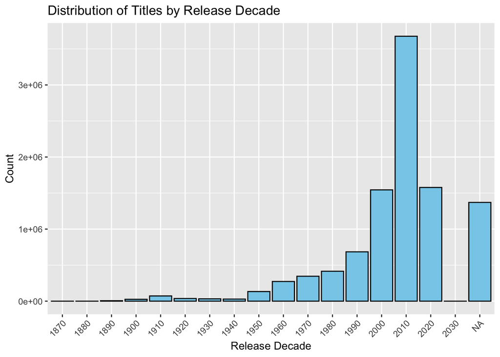

```r
ggplot(titles, aes(x = as.factor(Decade))) +
  geom_bar(fill = "skyblue", color = "black") +
  labs(title = "Distribution of Titles by Release Decade",
       x = "Release Decade",
       y = "Count") +
  theme(axis.text.x = element_text(angle = 45, hjust = 1))
```